Retained agreement notebook

# Drug Review

Complete saved code, figures, tables, console output, and alternative output representations from the retained notebook.

## Source and publication record

This HTML was packaged on **2026-09-10** from `03_agreement_drug.ipynb`. The saved analysis was not rerun: no fits, resampling, or model/API calls were made. Saved outputs and source wording describe the retained notebook and are not newly computed results or a new scientific validation.

| Frozen source SHA-256 | `a6a674469e1dee7f533b9f861c5cfcef822872e857eb46bd26830c45478b540b` |
| --- | --- |
| Retained content | 33 cells; 21 code cells; 34 saved output records; 11 embedded PNG figures |
| Saved kernel / language | Python 3 / Python 3.10.0 |
| Saved cell timestamps (UTC) | 2026-04-20T15:19:39.236Z through 2026-04-20T15:20:02.410Z |

All code cells appear expanded below. Every saved output record is retained; alternative plain-text output and Colab summary representations are available in disclosure panels. Notebook Markdown is rendered with its original text also available. Embedded figures and page styling require no network connection.

**Publication sanitation:** the original private project-directory prefix was replaced by `.` in 4 source/output occurrences. Relative filenames and the generic Colab mount location remain visible. These path substitutions are packaging edits, not recorded analysis executions. Account identities, timezone, and notebook cell/output identifiers from cell metadata are omitted; safe execution status, timestamps, and elapsed metadata are shown below. Colab-only controls and scripts are inert in the table view; their complete saved HTML is retained as escaped text in the corresponding disclosure panel. The hash above identifies the original frozen notebook bytes before sanitation.

Input data are linked through [the project OSF repository](https://osf.io/k9caj/). Source code preserves its historical input filenames and Colab setup; this static page does not execute them or certify that every historical input file is present on OSF.

**Saved per-cell execution metadata**

These are retained Colab fields, not execution measurements from this HTML export. The elapsed column preserves the numeric `elapsed` metadata value.

| Cell (zero-based) | Execution count | Status | Timestamp (UTC) | Elapsed (saved value) |
| --- | --- | --- | --- | --- |
| 1 | 1 | ok | 2026-04-20T15:19:39.236Z | 19810 |
| 3 | 2 | ok | 2026-04-20T15:19:40.396Z | 1157 |
| 5 | 3 | ok | 2026-04-20T15:19:40.944Z | 546 |
| 7 | 4 | ok | 2026-04-20T15:19:41.436Z | 480 |
| 8 | 5 | ok | 2026-04-20T15:19:43.030Z | 1582 |
| 9 | 6 | ok | 2026-04-20T15:19:44.229Z | 1198 |
| 10 | 7 | ok | 2026-04-20T15:19:46.639Z | 2409 |
| 12 | 8 | ok | 2026-04-20T15:19:46.802Z | 160 |
| 13 | 9 | ok | 2026-04-20T15:19:47.839Z | 1020 |
| 14 | 10 | ok | 2026-04-20T15:19:49.975Z | 2131 |
| 16 | 11 | ok | 2026-04-20T15:19:50.124Z | 151 |
| 17 | 12 | ok | 2026-04-20T15:19:52.796Z | 2662 |
| 19 | 13 | ok | 2026-04-20T15:19:53.009Z | 208 |
| 20 | 14 | ok | 2026-04-20T15:19:54.436Z | 1417 |
| 22 | 15 | ok | 2026-04-20T15:19:55.760Z | 1321 |
| 24 | 16 | ok | 2026-04-20T15:19:56.436Z | 675 |
| 26 | 17 | ok | 2026-04-20T15:19:56.508Z | 70 |
| 27 | 18 | ok | 2026-04-20T15:19:59.164Z | 2615 |
| 29 | 19 | ok | 2026-04-20T15:19:59.287Z | 122 |
| 30 | 20 | ok | 2026-04-20T15:20:01.965Z | 2679 |
| 32 | 21 | ok | 2026-04-20T15:20:02.410Z | 444 |

Cell 0 · markdown

# Drug Review: Agreement Analysis — G-Theory Faceted Labeling

Systematic comparison of G-Theory faceted labeling results against:

1. **Reference labels** — gpt-4o-mini at temp=0, seed=1001, rubric prompt (matching preliminary gpt-4o-mini screening conditions)
2. **Human ground-truth labels** — derived from user ratings (1–10 scale → 5-class sentiment)

**Entropy stratification:** Items were stratified-sampled based on Shannon entropy quantiles from gpt-4o-mini's self-reported probability vectors in a preliminary gpt-4o-mini screening pass. Entropy here is model-generated (not human-derived) and serves as an operational item-difficulty proxy.

## Analysis Levels

| Level | Grouping | Items per cell | Total pairs |
| --- | --- | --- | --- |
| 1 | Evaluator × Prompt × Temp | 100 (mode across 3 seeds) | 72 × 100 = 7,200 |
| 2 | Evaluator × Prompt | 600 (6 temps × 100) | 12 × 600 = 7,200 |
| 3 | Evaluator | 1,800 (3 prompts × 6 temps × 100) | 4 × 1,800 = 7,200 |
| 4 | Overall | 7,200 (all conditions pooled) | 7,200 |

## Experiment Design

- **Items:** 100 drug reviews, stratified by model-generated entropy (Q1/Q2/Q3/Q4)
- **5-class labels:** VERY_NEGATIVE, NEGATIVE, NEUTRAL, POSITIVE, VERY_POSITIVE
- **Evaluators (4):** gemini-2.5-flash, gpt-4o-mini, llama-70b, mistral-small
- **Prompts (3):** minimal, rubric, cot
- **Temperatures (6):** 0.0, 0.2, 0.4, 0.6, 0.8, 1.0
- **Seeds (3):** 1001, 2001, 3001
- **Total observations:** 21,600

**Original Markdown text**

```
# Drug Review: Agreement Analysis — G-Theory Faceted Labeling

Systematic comparison of G-Theory faceted labeling results against:
1. **Reference labels** — gpt-4o-mini at temp=0, seed=1001, rubric prompt (matching preliminary gpt-4o-mini screening conditions)
2. **Human ground-truth labels** — derived from user ratings (1–10 scale → 5-class sentiment)

**Entropy stratification:** Items were stratified-sampled based on Shannon entropy quantiles
from gpt-4o-mini's self-reported probability vectors in a preliminary gpt-4o-mini screening pass. Entropy here is
model-generated (not human-derived) and serves as an operational item-difficulty proxy.

## Analysis Levels
| Level | Grouping | Items per cell | Total pairs |
|-------|----------|---------------|-------------|
| 1 | Evaluator × Prompt × Temp | 100 (mode across 3 seeds) | 72 × 100 = 7,200 |
| 2 | Evaluator × Prompt | 600 (6 temps × 100) | 12 × 600 = 7,200 |
| 3 | Evaluator | 1,800 (3 prompts × 6 temps × 100) | 4 × 1,800 = 7,200 |
| 4 | Overall | 7,200 (all conditions pooled) | 7,200 |

## Experiment Design
- **Items:** 100 drug reviews, stratified by model-generated entropy (Q1/Q2/Q3/Q4)
- **5-class labels:** VERY_NEGATIVE, NEGATIVE, NEUTRAL, POSITIVE, VERY_POSITIVE
- **Evaluators (4):** gemini-2.5-flash, gpt-4o-mini, llama-70b, mistral-small
- **Prompts (3):** minimal, rubric, cot
- **Temperatures (6):** 0.0, 0.2, 0.4, 0.6, 0.8, 1.0
- **Seeds (3):** 1001, 2001, 3001
- **Total observations:** 21,600
```

Cell 1 · code · saved execution 1

```
import sys, os, warnings
warnings.filterwarnings('ignore')
import numpy as np
import pandas as pd
from pathlib import Path
from sklearn.metrics import (
    accuracy_score, f1_score, cohen_kappa_score,
    confusion_matrix, classification_report,
)
from scipy.stats import spearmanr, kruskal
import matplotlib.pyplot as plt
import seaborn as sns

# Google Drive mount (Colab)
from google.colab import drive
drive.mount('/content/drive')

BASE_DIR = Path("./03.DrugReview")
DATA_DIR = BASE_DIR / "data"
OUTPUTS_DIR = BASE_DIR / "outputs"
OUTPUTS_DIR.mkdir(parents=True, exist_ok=True)

# Shared utils
UTILS_DIR = Path(".")
sys.path.insert(0, str(UTILS_DIR))

# Dataset constants
LABELS = ["VERY_NEGATIVE", "NEGATIVE", "NEUTRAL", "POSITIVE", "VERY_POSITIVE"]
PREFIX = "drug"

sns.set_style("whitegrid")
plt.rcParams["figure.figsize"] = (12, 6)
plt.rcParams["figure.dpi"] = 120
plt.rcParams["font.size"] = 11

print("Setup complete.")
```

Saved output 1 · stream

```
Setup complete.
```

Cell 2 · markdown

## Load Data & Build Reference Labels

**Original Markdown text**

```
## Load Data & Build Reference Labels
```

Cell 3 · code · saved execution 2

```
# Load G-Theory results
df = pd.read_csv(DATA_DIR / "drug_labeling_final.csv")
# Filter to 4 main evaluators
EVALUATORS = ['gemini-2.5-flash', 'gpt-4o-mini', 'llama-70b', 'mistral-small']
df = df[df['evaluator'].isin(EVALUATORS)].copy()
print(f"G-Theory results: {len(df):,} rows")
print(f"Evaluators: {sorted(df['evaluator'].unique())}")
print(f"Prompts: {sorted(df['prompt_type'].unique())}")
print(f"Temperatures: {sorted(df['temperature'].unique())}")

# Load sample file (entropy strata + original ratings)
sample = pd.read_csv(DATA_DIR / "drug_sample_100.csv")

# ── Reference labels: gpt-4o-mini, temp=0, seed=1001, rubric ──
# Matches the conditions used in the preliminary gpt-4o-mini screening
ref = df[(df['evaluator'] == 'gpt-4o-mini') &
         (df['temperature'].astype(float) == 0.0) &
         (df['seed'].astype(int) == 1001) &
         (df['prompt_type'] == 'rubric')].copy()
ref['item_id'] = ref['item_id'].astype(str)
ref_labels = ref[['item_id', 'label']].rename(columns={'label': 'orig_label'})
print(f"\nReference labels (gpt-4o-mini/temp=0/seed=1001/rubric): {len(ref_labels)}")
print(f"  Distribution: {ref_labels['orig_label'].value_counts().to_dict()}")

# ── Human ground truth: original_rating → 5-class mapping ──
def rating_to_5class(r):
    if r <= 2: return 'VERY_NEGATIVE'
    elif r <= 4: return 'NEGATIVE'
    elif r <= 6: return 'NEUTRAL'
    elif r <= 8: return 'POSITIVE'
    else: return 'VERY_POSITIVE'

item_ref = sample[['item_id', 'entropy_stratum', 'original_rating']].copy()
item_ref['human_label'] = item_ref['original_rating'].apply(rating_to_5class)
item_ref = item_ref.drop(columns=['original_rating'])
item_ref['item_id'] = item_ref['item_id'].astype(str)
item_ref = item_ref.merge(ref_labels, on='item_id', how='inner')

# Clean: ensure no NaN in reference labels
item_ref['orig_label'] = item_ref['orig_label'].astype(str)
item_ref['human_label'] = item_ref['human_label'].astype(str)
item_ref = item_ref[~item_ref['orig_label'].isin(['nan', 'None', ''])].copy()
item_ref = item_ref[~item_ref['human_label'].isin(['nan', 'None', ''])].copy()
print(f"\nReference items: {len(item_ref)} (after NaN cleanup)")
print(f"Ref label dist:   {item_ref['orig_label'].value_counts().to_dict()}")
print(f"Human label dist: {item_ref['human_label'].value_counts().to_dict()}")

# Ensure df item_id is string
df['item_id'] = df['item_id'].astype(str)

# Merge reference labels into G-Theory results
df = df.merge(item_ref[['item_id', 'orig_label', 'human_label', 'entropy_stratum']],
              on='item_id', how='inner')
print(f"\nMerged G-Theory rows: {len(df):,} (expected 21,600)")
```

Saved output 1 · stream

```
G-Theory results: 21,600 rows
Evaluators: ['gemini-2.5-flash', 'gpt-4o-mini', 'llama-70b', 'mistral-small']
Prompts: ['cot', 'minimal', 'rubric']
Temperatures: [np.float64(0.0), np.float64(0.2), np.float64(0.4), np.float64(0.6), np.float64(0.8), np.float64(1.0)]

Reference labels (gpt-4o-mini/temp=0/seed=1001/rubric): 100
  Distribution: {'VERY_POSITIVE': 33, 'VERY_NEGATIVE': 27, 'POSITIVE': 25, 'NEGATIVE': 15}

Reference items: 100 (after NaN cleanup)
Ref label dist:   {'VERY_POSITIVE': 33, 'VERY_NEGATIVE': 27, 'POSITIVE': 25, 'NEGATIVE': 15}
Human label dist: {'VERY_POSITIVE': 42, 'POSITIVE': 19, 'VERY_NEGATIVE': 18, 'NEUTRAL': 11, 'NEGATIVE': 10}

Merged G-Theory rows: 21,600 (expected 21,600)
```

Cell 4 · markdown

## Helper Functions

**Original Markdown text**

```
## Helper Functions
```

Cell 5 · code · saved execution 3

```
# Severity ordering for quadratic-weighted kappa (matches Methods §2.6.1)
# Using the numeric ordinal severity preserves the clinical/sentiment
# gradient; falling back to raw string labels would apply quadratic weights
# over alphabetical ordering, which does not reflect the substantive scale.
SEVERITY_MAP = {"VERY_NEGATIVE": 1, "NEGATIVE": 2, "NEUTRAL": 3, "POSITIVE": 4, "VERY_POSITIVE": 5}


def compute_agreement(y_true, y_pred, labels=LABELS, severity_map=SEVERITY_MAP):
    """Compute agreement metrics between two label arrays.

    Cohen's quadratic-weighted kappa is computed over numeric severity
    values (severity_map) so the penalty reflects the ordinal severity
    gradient rather than alphabetical ordering of the raw labels.
    Agreement rate and macro-F1 still operate on the raw string labels.
    """
    y_true = [str(x) for x in y_true]
    y_pred = [str(x) for x in y_pred]
    agr = accuracy_score(y_true, y_pred)
    if severity_map is not None:
        y_true_sev = [severity_map[x] for x in y_true]
        y_pred_sev = [severity_map[x] for x in y_pred]
        kappa = cohen_kappa_score(y_true_sev, y_pred_sev, weights='quadratic')
    else:
        kappa = cohen_kappa_score(y_true, y_pred, weights='quadratic')
    f1 = f1_score(y_true, y_pred, average='macro', zero_division=0)
    cm = confusion_matrix(y_true, y_pred, labels=labels)
    return {'agreement': agr, 'kappa': kappa, 'macro_f1': f1, 'cm': cm, 'n': len(y_true)}


def get_mode_labels(df_subset):
    """Get mode label across seeds for each item in a condition cell."""
    return df_subset.groupby('item_id')['label'].agg(
        lambda x: x.mode().iloc[0] if len(x.mode()) > 0 else x.iloc[0]
    ).reset_index().rename(columns={'label': 'pred_label'})


# Build the core paired-labels DataFrame:
# For each evaluator x prompt x temp, take mode across 3 seeds -> 1 label per item
# This gives 100 items x 72 condition cells = 7,200 paired comparisons
paired = df.groupby(['evaluator', 'prompt_type', 'temperature', 'item_id'])['label'].agg(
    lambda x: x.mode().iloc[0]
).reset_index().rename(columns={'label': 'pred_label'})

paired = paired.merge(item_ref[['item_id', 'orig_label', 'human_label', 'entropy_stratum']],
                      on='item_id', how='inner')

# Ensure all label columns are clean strings
paired['pred_label'] = paired['pred_label'].astype(str)
paired['orig_label'] = paired['orig_label'].astype(str)
paired['human_label'] = paired['human_label'].astype(str)
paired = paired[~paired['orig_label'].isin(['nan', 'None', ''])].copy()
paired = paired[~paired['human_label'].isin(['nan', 'None', ''])].copy()

print(f"Paired comparisons: {len(paired):,} (expected 7,200 = 72 cells x 100 items)")
print(f"Evaluators: {sorted(paired['evaluator'].unique())}")
```

Saved output 1 · stream

```
Paired comparisons: 7,200 (expected 7,200 = 72 cells x 100 items)
Evaluators: ['gemini-2.5-flash', 'gpt-4o-mini', 'llama-70b', 'mistral-small']
```

Cell 6 · markdown

## Level 1: Per Condition Cell (Evaluator × Prompt × Temperature)

For each of the 72 condition cells (4 evaluators × 3 prompts × 6 temperatures), take mode label across 3 seeds → 100 items → compare vs original/human labels.

**Original Markdown text**

```
## Level 1: Per Condition Cell (Evaluator × Prompt × Temperature)

For each of the 72 condition cells (4 evaluators × 3 prompts × 6 temperatures),
take mode label across 3 seeds → 100 items → compare vs original/human labels.
```

Cell 7 · code · saved execution 4

```
# Compute metrics for each of 72 cells
level1_rows = []
for (ev, pt, temp), sub in paired.groupby(['evaluator', 'prompt_type', 'temperature']):
    m_orig = compute_agreement(sub['orig_label'], sub['pred_label'])
    m_human = compute_agreement(sub['human_label'], sub['pred_label'])
    level1_rows.append({
        'evaluator': ev, 'prompt_type': pt, 'temperature': temp,
        'agr_ref': round(m_orig['agreement'], 3),
        'kappa_ref': round(m_orig['kappa'], 3),
        'f1_ref': round(m_orig['macro_f1'], 3),
        'agr_human': round(m_human['agreement'], 3),
        'kappa_human': round(m_human['kappa'], 3),
        'f1_human': round(m_human['macro_f1'], 3),
        'n': m_orig['n'],
    })

level1 = pd.DataFrame(level1_rows)
print(f"Level 1: {len(level1)} cells (expected 72)")
print(f"\n=== Agreement Rate vs Reference: summary ===")
print(f"  Mean:   {level1['agr_ref'].mean():.3f}")
print(f"  Std:    {level1['agr_ref'].std():.3f}")
print(f"  Min:    {level1['agr_ref'].min():.3f}")
print(f"  Max:    {level1['agr_ref'].max():.3f}")
print(f"\n=== Weighted Kappa vs Reference: summary ===")
print(f"  Mean:   {level1['kappa_ref'].mean():.3f}")
print(f"  Std:    {level1['kappa_ref'].std():.3f}")

# Best and worst cells
best = level1.loc[level1['agr_ref'].idxmax()]
worst = level1.loc[level1['agr_ref'].idxmin()]
print(f"\nBest cell:  {best['evaluator']} / {best['prompt_type']} / t={best['temperature']} -> acc={best['agr_ref']:.3f}")
print(f"Worst cell: {worst['evaluator']} / {worst['prompt_type']} / t={worst['temperature']} -> acc={worst['agr_ref']:.3f}")
```

Saved output 1 · stream

```
Level 1: 72 cells (expected 72)

=== Agreement Rate vs Reference: summary ===
  Mean:   0.703
  Std:    0.138
  Min:    0.240
  Max:    0.960

=== Weighted Kappa vs Reference: summary ===
  Mean:   0.914
  Std:    0.061

Best cell:  gpt-4o-mini / rubric / t=0.0 -> acc=0.960
Worst cell: mistral-small / cot / t=1.0 -> acc=0.240
```

Cell 8 · code · saved execution 5

```
# Heatmaps: Agreement Rate vs Reference (evaluator x temperature, one per prompt)
fig, axes = plt.subplots(1, 3, figsize=(20, 5), sharey=True)

for ax_idx, pt in enumerate(['minimal', 'rubric', 'cot']):
    sub = level1[level1['prompt_type'] == pt]
    pivot = sub.pivot(index='evaluator', columns='temperature', values='agr_ref')
    sns.heatmap(pivot, annot=True, fmt='.2f', cmap='RdYlGn', vmin=0.2, vmax=1.0,
                ax=axes[ax_idx], cbar=False)
    axes[ax_idx].set_title(f'{pt.title()} Prompt')
    axes[ax_idx].set_xlabel('Temperature')
    if ax_idx == 0:
        axes[ax_idx].set_ylabel('Evaluator')
    else:
        axes[ax_idx].set_ylabel('')

fig.suptitle('Level 1: Agreement Rate vs Reference (4o-mini/t=0/s=1001) (100 items per cell)', fontsize=14, y=1.02)
fig.subplots_adjust(right=0.91)
cbar_ax = fig.add_axes([0.92, 0.15, 0.015, 0.7])
sm = plt.cm.ScalarMappable(cmap='RdYlGn', norm=plt.Normalize(vmin=0.2, vmax=1.0))
fig.colorbar(sm, cax=cbar_ax)
plt.savefig(OUTPUTS_DIR / 'drug_agreement_L1_agreement_ref.png', dpi=150, bbox_inches='tight')
plt.show()
```

Saved output 1 · display_data

**Saved plain-text representation**

```
<Figure size 2400x600 with 4 Axes>
```

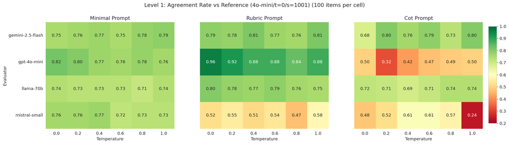

Cell 9 · code · saved execution 6

```
# Heatmaps: Weighted kappa vs Reference
fig, axes = plt.subplots(1, 3, figsize=(20, 5), sharey=True)

for ax_idx, pt in enumerate(['minimal', 'rubric', 'cot']):
    sub = level1[level1['prompt_type'] == pt]
    pivot = sub.pivot(index='evaluator', columns='temperature', values='kappa_ref')
    sns.heatmap(pivot, annot=True, fmt='.2f', cmap='RdYlGn', vmin=0, vmax=1.0,
                ax=axes[ax_idx], cbar=False)
    axes[ax_idx].set_title(f'{pt.title()} Prompt')
    axes[ax_idx].set_xlabel('Temperature')
    if ax_idx == 0:
        axes[ax_idx].set_ylabel('Evaluator')
    else:
        axes[ax_idx].set_ylabel('')

fig.suptitle("Level 1: Weighted κ vs Reference (4o-mini/t=0/s=1001) (100 items per cell)", fontsize=14, y=1.02)
fig.subplots_adjust(right=0.91)
cbar_ax = fig.add_axes([0.92, 0.15, 0.015, 0.7])
sm = plt.cm.ScalarMappable(cmap='RdYlGn', norm=plt.Normalize(vmin=0, vmax=1.0))
fig.colorbar(sm, cax=cbar_ax)
plt.savefig(OUTPUTS_DIR / 'drug_agreement_L1_kappa_ref.png', dpi=150, bbox_inches='tight')
plt.show()
```

Saved output 1 · display_data

**Saved plain-text representation**

```
<Figure size 2400x600 with 4 Axes>
```

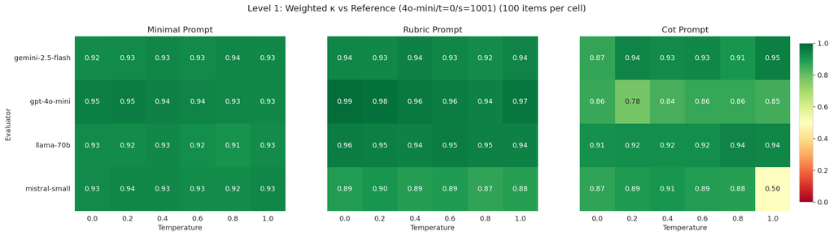

Cell 10 · code · saved execution 7

```
# Heatmaps: Agreement Rate vs Human Ground Truth
fig, axes = plt.subplots(1, 3, figsize=(20, 5), sharey=True)

for ax_idx, pt in enumerate(['minimal', 'rubric', 'cot']):
    sub = level1[level1['prompt_type'] == pt]
    pivot = sub.pivot(index='evaluator', columns='temperature', values='agr_human')
    sns.heatmap(pivot, annot=True, fmt='.2f', cmap='RdYlGn', vmin=0.2, vmax=1.0,
                ax=axes[ax_idx], cbar=False)
    axes[ax_idx].set_title(f'{pt.title()} Prompt')
    axes[ax_idx].set_xlabel('Temperature')
    if ax_idx == 0:
        axes[ax_idx].set_ylabel('Evaluator')
    else:
        axes[ax_idx].set_ylabel('')

fig.suptitle('Level 1: Agreement Rate vs Human Labels (100 items per cell)', fontsize=14, y=1.02)
fig.subplots_adjust(right=0.91)
cbar_ax = fig.add_axes([0.92, 0.15, 0.015, 0.7])
sm = plt.cm.ScalarMappable(cmap='RdYlGn', norm=plt.Normalize(vmin=0.2, vmax=1.0))
fig.colorbar(sm, cax=cbar_ax)
plt.savefig(OUTPUTS_DIR / 'drug_agreement_L1_agreement_human.png', dpi=150, bbox_inches='tight')
plt.show()
```

Saved output 1 · display_data

**Saved plain-text representation**

```
<Figure size 2400x600 with 4 Axes>
```

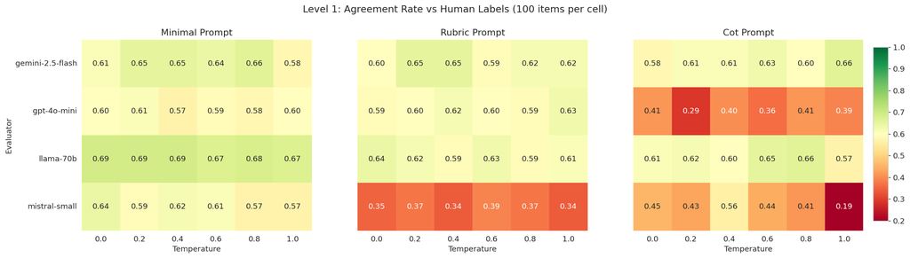

Cell 11 · markdown

## Level 2: Evaluator × Prompt (600 paired comparisons each)

For each evaluator × prompt combination, stack all 6 temperature conditions: each item appears 6 times (one mode-label per temperature), yielding 600 paired comparisons.

**Original Markdown text**

```
## Level 2: Evaluator × Prompt (600 paired comparisons each)

For each evaluator × prompt combination, stack all 6 temperature conditions:
each item appears 6 times (one mode-label per temperature), yielding 600 paired comparisons.
```

Cell 12 · code · saved execution 8

```
# Level 2 metrics: evaluator x prompt, n=600 each
level2_rows = []
for (ev, pt), sub in paired.groupby(['evaluator', 'prompt_type']):
    m_orig = compute_agreement(sub['orig_label'], sub['pred_label'])
    m_human = compute_agreement(sub['human_label'], sub['pred_label'])
    level2_rows.append({
        'evaluator': ev, 'prompt_type': pt,
        'agr_ref': round(m_orig['agreement'], 3),
        'kappa_ref': round(m_orig['kappa'], 3),
        'f1_ref': round(m_orig['macro_f1'], 3),
        'agr_human': round(m_human['agreement'], 3),
        'kappa_human': round(m_human['kappa'], 3),
        'f1_human': round(m_human['macro_f1'], 3),
        'n': m_orig['n'],
    })

level2 = pd.DataFrame(level2_rows)
print("=== Level 2: Evaluator \u00d7 Prompt (n=600 per cell) ===")
display(level2)
```

Saved output 1 · stream

```
=== Level 2: Evaluator × Prompt (n=600 per cell) ===
```

Saved output 2 · display_data

**Saved plain-text representation**

```
           evaluator prompt_type  agr_ref  kappa_ref  f1_ref  agr_human  \
0   gemini-2.5-flash         cot    0.760      0.921   0.618      0.615
1   gemini-2.5-flash     minimal    0.767      0.929   0.611      0.632
2   gemini-2.5-flash      rubric    0.787      0.935   0.616      0.622
3        gpt-4o-mini         cot    0.450      0.842   0.391      0.377
4        gpt-4o-mini     minimal    0.782      0.943   0.627      0.592
5        gpt-4o-mini      rubric    0.893      0.970   0.710      0.605
6          llama-70b         cot    0.718      0.924   0.579      0.618
7          llama-70b     minimal    0.730      0.922   0.576      0.682
8          llama-70b      rubric    0.775      0.950   0.613      0.613
9      mistral-small         cot    0.505      0.834   0.449      0.413
10     mistral-small     minimal    0.745      0.930   0.598      0.600
11     mistral-small      rubric    0.528      0.887   0.409      0.360

    kappa_human  f1_human    n
0         0.826     0.522  600
1         0.841     0.535  600
2         0.843     0.509  600
3         0.733     0.379  600
4         0.861     0.504  600
5         0.848     0.479  600
6         0.867     0.561  600
7         0.889     0.613  600
8         0.866     0.520  600
9         0.736     0.410  600
10        0.857     0.537  600
11        0.777     0.335  600
```

|  | evaluator | prompt_type | agr_ref | kappa_ref | f1_ref | agr_human | kappa_human | f1_human | n |
| --- | --- | --- | --- | --- | --- | --- | --- | --- | --- |
| 0 | gemini-2.5-flash | cot | 0.760 | 0.921 | 0.618 | 0.615 | 0.826 | 0.522 | 600 |
| 1 | gemini-2.5-flash | minimal | 0.767 | 0.929 | 0.611 | 0.632 | 0.841 | 0.535 | 600 |
| 2 | gemini-2.5-flash | rubric | 0.787 | 0.935 | 0.616 | 0.622 | 0.843 | 0.509 | 600 |
| 3 | gpt-4o-mini | cot | 0.450 | 0.842 | 0.391 | 0.377 | 0.733 | 0.379 | 600 |
| 4 | gpt-4o-mini | minimal | 0.782 | 0.943 | 0.627 | 0.592 | 0.861 | 0.504 | 600 |
| 5 | gpt-4o-mini | rubric | 0.893 | 0.970 | 0.710 | 0.605 | 0.848 | 0.479 | 600 |
| 6 | llama-70b | cot | 0.718 | 0.924 | 0.579 | 0.618 | 0.867 | 0.561 | 600 |
| 7 | llama-70b | minimal | 0.730 | 0.922 | 0.576 | 0.682 | 0.889 | 0.613 | 600 |
| 8 | llama-70b | rubric | 0.775 | 0.950 | 0.613 | 0.613 | 0.866 | 0.520 | 600 |
| 9 | mistral-small | cot | 0.505 | 0.834 | 0.449 | 0.413 | 0.736 | 0.410 | 600 |
| 10 | mistral-small | minimal | 0.745 | 0.930 | 0.598 | 0.600 | 0.857 | 0.537 | 600 |
| 11 | mistral-small | rubric | 0.528 | 0.887 | 0.409 | 0.360 | 0.777 | 0.335 | 600 |

**Complete saved HTML representation (inert source)**

[output not shown]

**Saved application/vnd.google.colaboratory.intrinsic+json representation**

[output not shown]

Cell 13 · code · saved execution 9

```
# Grouped bar chart: Level 2
fig, axes = plt.subplots(1, 2, figsize=(16, 6))

# Pivot for plotting
for ax_idx, (metric, title) in enumerate([('agr_ref', 'Agreement Rate vs Reference'),
                                            ('kappa_ref', "Weighted κ vs Reference")]):
    pivot = level2.pivot(index='evaluator', columns='prompt_type', values=metric)
    pivot = pivot[['minimal', 'rubric', 'cot']]
    pivot.plot(kind='bar', ax=axes[ax_idx], rot=30, width=0.7)
    axes[ax_idx].set_title(title)
    axes[ax_idx].set_ylabel(metric.split('_')[0].title())
    axes[ax_idx].legend(title='Prompt')
    axes[ax_idx].set_ylim(0, 1.05)

fig.suptitle('Level 2: Agreement by Evaluator \u00d7 Prompt (n=600 per cell)', fontsize=14, y=1.02)
plt.tight_layout()
plt.savefig(OUTPUTS_DIR / 'drug_agreement_L2_bar.png', dpi=150, bbox_inches='tight')
plt.show()
```

Saved output 1 · display_data

**Saved plain-text representation**

```
<Figure size 1920x720 with 2 Axes>
```

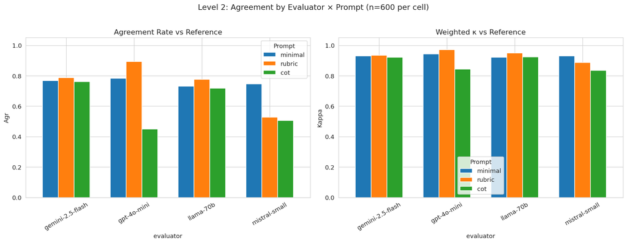

Cell 14 · code · saved execution 10

```
# Confusion matrices: each evaluator at rubric prompt vs original
evaluators = sorted(paired['evaluator'].unique())
fig, axes = plt.subplots(1, len(evaluators), figsize=(5.5 * len(evaluators), 5))

for ax_idx, ev in enumerate(evaluators):
    sub = paired[(paired['evaluator'] == ev) & (paired['prompt_type'] == 'rubric')]
    cm = confusion_matrix(sub['orig_label'], sub['pred_label'], labels=LABELS)
    sns.heatmap(cm, annot=True, fmt='d', cmap='Blues', xticklabels=LABELS, yticklabels=LABELS,
                ax=axes[ax_idx])
    agr = accuracy_score(sub['orig_label'], sub['pred_label'])
    axes[ax_idx].set_title(f'{ev}\nagr={agr:.1%}')
    axes[ax_idx].set_xlabel('G-Theory')
    axes[ax_idx].set_xticklabels(LABELS, rotation=30, ha='right')
    axes[ax_idx].set_yticklabels(LABELS, rotation=30, ha='right')
    if ax_idx == 0:
        axes[ax_idx].set_ylabel('Original')

fig.suptitle('Level 2: Confusion Matrices \u2014 Rubric Prompt vs Reference (n=600)', fontsize=13, y=1.05)
plt.tight_layout()
plt.savefig(OUTPUTS_DIR / 'drug_agreement_L2_cm_rubric.png', dpi=150, bbox_inches='tight')
plt.show()
```

Saved output 1 · display_data

**Saved plain-text representation**

```
<Figure size 2640x600 with 8 Axes>
```

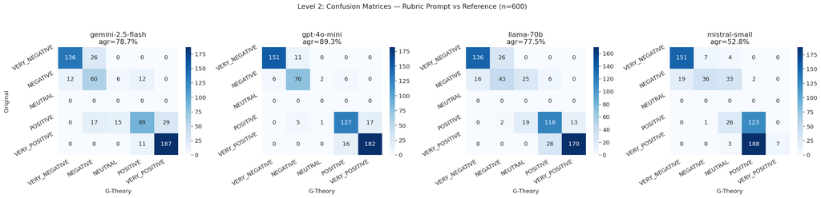

Cell 15 · markdown

## Level 3: Per Evaluator (1,800 paired comparisons each)

For each evaluator, stack all prompt × temperature conditions: each item appears 18 times (3 prompts × 6 temps), yielding 1,800 paired comparisons.

**Original Markdown text**

```
## Level 3: Per Evaluator (1,800 paired comparisons each)

For each evaluator, stack all prompt × temperature conditions:
each item appears 18 times (3 prompts × 6 temps), yielding 1,800 paired comparisons.
```

Cell 16 · code · saved execution 11

```
# Level 3 metrics: per evaluator, n=1800 each
level3_rows = []
for ev, sub in paired.groupby('evaluator'):
    m_orig = compute_agreement(sub['orig_label'], sub['pred_label'])
    m_human = compute_agreement(sub['human_label'], sub['pred_label'])
    level3_rows.append({
        'evaluator': ev,
        'agr_ref': round(m_orig['agreement'], 3),
        'kappa_ref': round(m_orig['kappa'], 3),
        'f1_ref': round(m_orig['macro_f1'], 3),
        'agr_human': round(m_human['agreement'], 3),
        'kappa_human': round(m_human['kappa'], 3),
        'f1_human': round(m_human['macro_f1'], 3),
        'n': m_orig['n'],
    })

level3 = pd.DataFrame(level3_rows)
print("=== Level 3: Per Evaluator (n=1,800 per evaluator) ===")
display(level3)
```

Saved output 1 · stream

```
=== Level 3: Per Evaluator (n=1,800 per evaluator) ===
```

Saved output 2 · display_data

**Saved plain-text representation**

```
          evaluator  agr_ref  kappa_ref  f1_ref  agr_human  kappa_human  \
0  gemini-2.5-flash    0.771      0.929   0.615      0.623        0.837
1       gpt-4o-mini    0.708      0.924   0.579      0.524        0.819
2         llama-70b    0.741      0.932   0.589      0.638        0.874
3     mistral-small    0.593      0.886   0.500      0.458        0.792

   f1_human     n
0     0.522  1800
1     0.466  1800
2     0.566  1800
3     0.441  1800
```

|  | evaluator | agr_ref | kappa_ref | f1_ref | agr_human | kappa_human | f1_human | n |
| --- | --- | --- | --- | --- | --- | --- | --- | --- |
| 0 | gemini-2.5-flash | 0.771 | 0.929 | 0.615 | 0.623 | 0.837 | 0.522 | 1800 |
| 1 | gpt-4o-mini | 0.708 | 0.924 | 0.579 | 0.524 | 0.819 | 0.466 | 1800 |
| 2 | llama-70b | 0.741 | 0.932 | 0.589 | 0.638 | 0.874 | 0.566 | 1800 |
| 3 | mistral-small | 0.593 | 0.886 | 0.500 | 0.458 | 0.792 | 0.441 | 1800 |

**Complete saved HTML representation (inert source)**

[output not shown]

**Saved application/vnd.google.colaboratory.intrinsic+json representation**

[output not shown]

Cell 17 · code · saved execution 12

```
# Dual bar chart: vs original and vs human
fig, axes = plt.subplots(1, 2, figsize=(14, 6))

evaluators = level3['evaluator'].tolist()
x = np.arange(len(evaluators))
width = 0.35

for ax_idx, (m1, m2, ylabel) in enumerate([
    ('agr_ref', 'agr_human', 'Agreement Rate'),
    ('kappa_ref', 'kappa_human', "Weighted κ (quadratic)"),
]):
    bars1 = axes[ax_idx].bar(x - width/2, level3[m1], width,
                              label='vs Reference', color='steelblue', alpha=0.8)
    bars2 = axes[ax_idx].bar(x + width/2, level3[m2], width,
                              label='vs Human', color='coral', alpha=0.8)
    axes[ax_idx].set_xticks(x)
    axes[ax_idx].set_xticklabels(evaluators, rotation=30, ha='right')
    axes[ax_idx].set_ylabel(ylabel)
    axes[ax_idx].set_title(f'{ylabel} by Evaluator (n=1,800)')
    axes[ax_idx].legend()
    if 'acc' in m1:
        axes[ax_idx].set_ylim(0, 1.1)

    for bar in bars1:
        h = bar.get_height()
        axes[ax_idx].text(bar.get_x() + bar.get_width()/2., h + 0.02,
                          '{:.1%}'.format(h) if 'acc' in m1 else '{:.3f}'.format(h),
                          ha='center', va='bottom', fontsize=8)
    for bar in bars2:
        h = bar.get_height()
        axes[ax_idx].text(bar.get_x() + bar.get_width()/2., h + 0.02,
                          '{:.1%}'.format(h) if 'acc' in m1 else '{:.3f}'.format(h),
                          ha='center', va='bottom', fontsize=8)

fig.suptitle('Level 3: Per-Evaluator Agreement (n=1,800)', fontsize=14, y=1.02)
plt.tight_layout()
plt.savefig(OUTPUTS_DIR / 'drug_agreement_L3_bar.png', dpi=150, bbox_inches='tight')
plt.show()
```

Saved output 1 · display_data

**Saved plain-text representation**

```
<Figure size 1680x720 with 2 Axes>
```

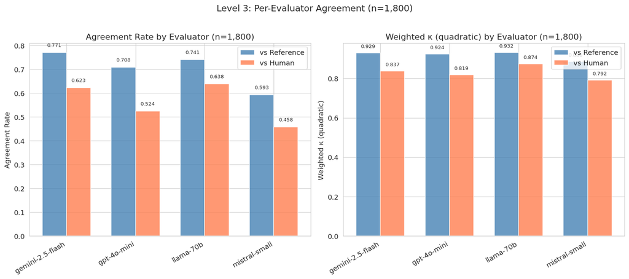

Cell 18 · markdown

## Level 4: Overall (7,200 paired comparisons)

Pool all evaluators × prompts × temperatures. Grand confusion matrix and classification report.

**Original Markdown text**

```
## Level 4: Overall (7,200 paired comparisons)

Pool all evaluators × prompts × temperatures. Grand confusion matrix and classification report.
```

Cell 19 · code · saved execution 13

```
# Overall metrics
m_orig = compute_agreement(paired['orig_label'], paired['pred_label'])
m_human = compute_agreement(paired['human_label'], paired['pred_label'])

print("=== Level 4: Overall Agreement (n=7,200) ===")
print(f"  vs Reference:  agr={m_orig['agreement']:.3f}  κ_w={m_orig['kappa']:.3f}  F1={m_orig['macro_f1']:.3f}")
print(f"  vs Human:     agr={m_human['agreement']:.3f}  κ_w={m_human['kappa']:.3f}  F1={m_human['macro_f1']:.3f}")

print(f"\n=== Classification Report vs Reference ===")
print(classification_report(paired['orig_label'].astype(str), paired['pred_label'].astype(str),
                            labels=LABELS, digits=3))

print(f"\n=== Classification Report vs Human ===")
print(classification_report(paired['human_label'].astype(str), paired['pred_label'].astype(str),
                            labels=LABELS, digits=3))
```

Saved output 1 · stream

```
=== Level 4: Overall Agreement (n=7,200) ===
  vs Reference:  agr=0.703  κ_w=0.918  F1=0.574
  vs Human:     agr=0.561  κ_w=0.831  F1=0.501

=== Classification Report vs Reference ===
               precision    recall  f1-score   support

VERY_NEGATIVE      0.947     0.749     0.837      1944
     NEGATIVE      0.541     0.627     0.581      1080
      NEUTRAL      0.000     0.000     0.000         0
     POSITIVE      0.621     0.704     0.660      1800
VERY_POSITIVE      0.917     0.700     0.794      2376

     accuracy                          0.703      7200
    macro avg      0.605     0.556     0.574      7200
 weighted avg      0.795     0.703     0.740      7200


=== Classification Report vs Human ===
               precision    recall  f1-score   support

VERY_NEGATIVE      0.670     0.795     0.727      1296
     NEGATIVE      0.319     0.554     0.405       720
      NEUTRAL      0.262     0.184     0.216       792
     POSITIVE      0.386     0.576     0.462      1368
VERY_POSITIVE      0.923     0.554     0.692      3024

     accuracy                          0.561      7200
    macro avg      0.512     0.533     0.501      7200
 weighted avg      0.642     0.561     0.574      7200
```

Cell 20 · code · saved execution 14

```
# Grand confusion matrices (normalized by rows)
fig, axes = plt.subplots(1, 2, figsize=(15, 6))

for ax_idx, (ref_col, title) in enumerate([
    ('orig_label', 'vs Reference (4o-mini/t=0/s=1001)'),
    ('human_label', 'vs Human Labels'),
]):
    cm = confusion_matrix(paired[ref_col], paired['pred_label'], labels=LABELS)
    cm_norm = cm.astype(float) / cm.sum(axis=1, keepdims=True)
    sns.heatmap(cm_norm, annot=True, fmt='.2f', cmap='Blues',
                xticklabels=LABELS, yticklabels=LABELS, ax=axes[ax_idx])
    # Add raw counts as secondary annotation
    for i in range(len(LABELS)):
        for j in range(len(LABELS)):
            axes[ax_idx].text(j + 0.5, i + 0.75, f'({cm[i,j]})',
                              ha='center', va='center', fontsize=8, color='gray')
    axes[ax_idx].set_xlabel('G-Theory Prediction')
    axes[ax_idx].set_ylabel('Reference Label')
    axes[ax_idx].set_title(title)

fig.suptitle('Level 4: Grand Confusion Matrices (row-normalized, n=7,200)', fontsize=14, y=1.02)
plt.tight_layout()
plt.savefig(OUTPUTS_DIR / 'drug_agreement_L4_cm.png', dpi=150, bbox_inches='tight')
plt.show()
```

Saved output 1 · display_data

**Saved plain-text representation**

```
<Figure size 1800x720 with 4 Axes>
```

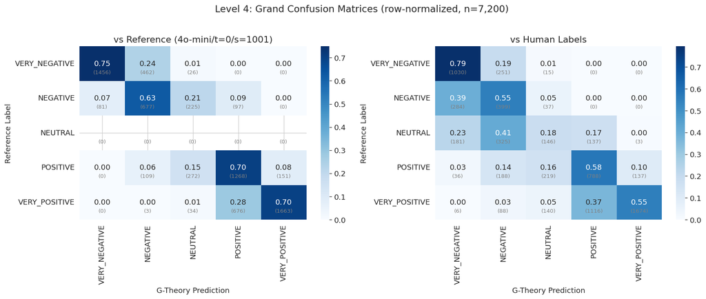

Cell 21 · markdown

## Temperature Sensitivity

Does agreement degrade at higher temperatures? Pooled across evaluators and prompts.

**Original Markdown text**

```
## Temperature Sensitivity

Does agreement degrade at higher temperatures? Pooled across evaluators and prompts.
```

Cell 22 · code · saved execution 15

```
# Metrics per temperature
temp_rows = []
for temp, sub in paired.groupby('temperature'):
    m_orig = compute_agreement(sub['orig_label'], sub['pred_label'])
    m_human = compute_agreement(sub['human_label'], sub['pred_label'])
    temp_rows.append({
        'temperature': temp,
        'agr_ref': m_orig['agreement'], 'kappa_ref': m_orig['kappa'],
        'agr_human': m_human['agreement'], 'kappa_human': m_human['kappa'],
        'n': m_orig['n'],
    })

temp_df = pd.DataFrame(temp_rows)
print("=== Agreement by Temperature ===")
display(temp_df.round(3))

# Line plot
fig, axes = plt.subplots(1, 2, figsize=(14, 5))
for ax_idx, (m1, m2, ylabel) in enumerate([
    ('agr_ref', 'agr_human', 'Agreement Rate'),
    ('kappa_ref', 'kappa_human', "Weighted κ (quadratic)"),
]):
    axes[ax_idx].plot(temp_df['temperature'], temp_df[m1], 'o-', label='vs Reference', color='steelblue')
    axes[ax_idx].plot(temp_df['temperature'], temp_df[m2], 's--', label='vs Human', color='coral')
    axes[ax_idx].set_xlabel('Temperature')
    axes[ax_idx].set_ylabel(ylabel)
    axes[ax_idx].set_title(f'{ylabel} vs Temperature')
    axes[ax_idx].legend()

fig.suptitle('Temperature Sensitivity: Agreement Stability', fontsize=14, y=1.02)
plt.tight_layout()
plt.savefig(OUTPUTS_DIR / 'drug_agreement_temp_sensitivity.png', dpi=150, bbox_inches='tight')
plt.show()
```

Saved output 1 · stream

```
=== Agreement by Temperature ===
```

Saved output 2 · display_data

**Saved plain-text representation**

```
   temperature  agr_ref  kappa_ref  agr_human  kappa_human     n
0          0.0    0.710      0.919      0.564        0.833  1200
1          0.2    0.702      0.923      0.561        0.835  1200
2          0.4    0.708      0.924      0.575        0.836  1200
3          0.6    0.710      0.925      0.567        0.838  1200
4          0.8    0.697      0.917      0.562        0.833  1200
5          1.0    0.693      0.902      0.536        0.813  1200
```

|  | temperature | agr_ref | kappa_ref | agr_human | kappa_human | n |
| --- | --- | --- | --- | --- | --- | --- |
| 0 | 0.0 | 0.710 | 0.919 | 0.564 | 0.833 | 1200 |
| 1 | 0.2 | 0.702 | 0.923 | 0.561 | 0.835 | 1200 |
| 2 | 0.4 | 0.708 | 0.924 | 0.575 | 0.836 | 1200 |
| 3 | 0.6 | 0.710 | 0.925 | 0.567 | 0.838 | 1200 |
| 4 | 0.8 | 0.697 | 0.917 | 0.562 | 0.833 | 1200 |
| 5 | 1.0 | 0.693 | 0.902 | 0.536 | 0.813 | 1200 |

**Complete saved HTML representation (inert source)**

[output not shown]

**Saved application/vnd.google.colaboratory.intrinsic+json representation**

[output not shown]

Saved output 3 · display_data

**Saved plain-text representation**

```
<Figure size 1680x600 with 2 Axes>
```

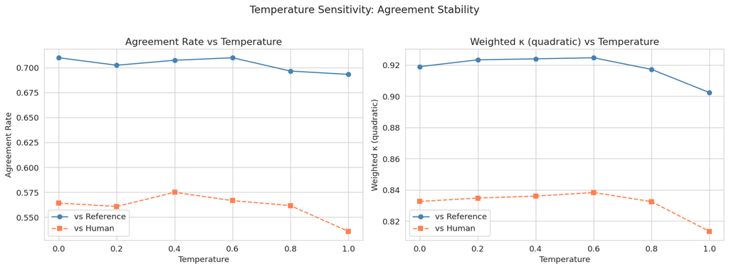

Cell 23 · markdown

## Prompt Effect

Does prompt type (minimal / rubric / cot) affect agreement? Pooled across evaluators and temperatures.

**Original Markdown text**

```
## Prompt Effect

Does prompt type (minimal / rubric / cot) affect agreement? Pooled across evaluators and temperatures.
```

Cell 24 · code · saved execution 16

```
# Metrics per prompt type
prompt_rows = []
for pt, sub in paired.groupby('prompt_type'):
    m_orig = compute_agreement(sub['orig_label'], sub['pred_label'])
    m_human = compute_agreement(sub['human_label'], sub['pred_label'])
    prompt_rows.append({
        'prompt_type': pt,
        'agr_ref': m_orig['agreement'], 'kappa_ref': m_orig['kappa'],
        'f1_ref': m_orig['macro_f1'],
        'agr_human': m_human['agreement'], 'kappa_human': m_human['kappa'],
        'f1_human': m_human['macro_f1'],
        'n': m_orig['n'],
    })

prompt_df = pd.DataFrame(prompt_rows)
print("=== Agreement by Prompt Type ===")
display(prompt_df.round(3))

# Bar chart
fig, ax = plt.subplots(figsize=(10, 5))
x = np.arange(len(prompt_df))
width = 0.2
ax.bar(x - 1.5*width, prompt_df['agr_ref'], width, label='Agr vs Ref', color='steelblue')
ax.bar(x - 0.5*width, prompt_df['agr_human'], width, label='Agr vs Human', color='coral')
ax.bar(x + 0.5*width, prompt_df['kappa_ref'], width, label='κ_w vs Orig', color='steelblue', alpha=0.5)
ax.bar(x + 1.5*width, prompt_df['kappa_human'], width, label='κ_w vs Human', color='coral', alpha=0.5)
ax.set_xticks(x)
ax.set_xticklabels(prompt_df['prompt_type'])
ax.set_ylabel('Score')
ax.set_title('Agreement by Prompt Type')
ax.legend()
plt.tight_layout()
plt.savefig(OUTPUTS_DIR / 'drug_agreement_prompt_effect.png', dpi=150, bbox_inches='tight')
plt.show()
```

Saved output 1 · stream

```
=== Agreement by Prompt Type ===
```

Saved output 2 · display_data

**Saved plain-text representation**

```
  prompt_type  agr_ref  kappa_ref  f1_ref  agr_human  kappa_human  f1_human  \
0         cot    0.608      0.884   0.514      0.506        0.794     0.472
1     minimal    0.756      0.931   0.605      0.626        0.862     0.547
2      rubric    0.746      0.937   0.602      0.550        0.835     0.476

      n
0  2400
1  2400
2  2400
```

|  | prompt_type | agr_ref | kappa_ref | f1_ref | agr_human | kappa_human | f1_human | n |
| --- | --- | --- | --- | --- | --- | --- | --- | --- |
| 0 | cot | 0.608 | 0.884 | 0.514 | 0.506 | 0.794 | 0.472 | 2400 |
| 1 | minimal | 0.756 | 0.931 | 0.605 | 0.626 | 0.862 | 0.547 | 2400 |
| 2 | rubric | 0.746 | 0.937 | 0.602 | 0.550 | 0.835 | 0.476 | 2400 |

**Complete saved HTML representation (inert source)**

[output not shown]

**Saved application/vnd.google.colaboratory.intrinsic+json representation**

[output not shown]

Saved output 3 · display_data

**Saved plain-text representation**

```
<Figure size 1200x600 with 1 Axes>
```

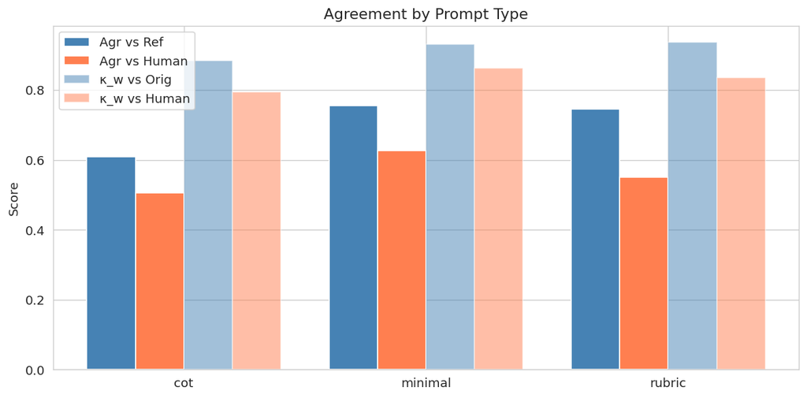

Cell 25 · markdown

## Item-Level Disagreement Analysis

**Original Markdown text**

[output not shown]

Cell 26 · code · saved execution 17

```
# Per-item agreement rate across all 72 condition cells
item_agree = paired.groupby('item_id').apply(
    lambda g: pd.Series({
        'agree_rate_ref': (g['pred_label'] == g['orig_label']).mean(),
        'agree_rate_human': (g['pred_label'] == g['human_label']).mean(),
        'n_conditions': len(g),
        'orig_label': g['orig_label'].iloc[0],
        'human_label': g['human_label'].iloc[0],
        'most_common_pred': g['pred_label'].mode().iloc[0],
        'entropy_stratum': g['entropy_stratum'].iloc[0],
    })
).reset_index()

print(f"=== Item-Level Agreement Summary (n={len(item_agree)}) ===")
print(f"  Mean agree rate vs original: {item_agree['agree_rate_ref'].mean():.3f}")
print(f"  Mean agree rate vs human:    {item_agree['agree_rate_human'].mean():.3f}")
print(f"  Items with 100% agreement (orig): {(item_agree['agree_rate_ref'] == 1.0).sum()}")
print(f"  Items with <50% agreement (orig): {(item_agree['agree_rate_ref'] < 0.5).sum()}")

print(f"\n=== Top 10 Most Disagreed Items (vs Reference) ===")
worst_items = item_agree.nsmallest(10, 'agree_rate_ref')
display(worst_items[['item_id', 'orig_label', 'human_label', 'most_common_pred',
                      'agree_rate_ref', 'agree_rate_human', 'entropy_stratum']])
```

Saved output 1 · stream

```
=== Item-Level Agreement Summary (n=100) ===
  Mean agree rate vs original: 0.703
  Mean agree rate vs human:    0.561
  Items with 100% agreement (orig): 0
  Items with <50% agreement (orig): 20

=== Top 10 Most Disagreed Items (vs Reference) ===
```

Saved output 2 · display_data

**Saved plain-text representation**

```
   item_id     orig_label    human_label most_common_pred  agree_rate_ref  \
38  199865       NEGATIVE        NEUTRAL         POSITIVE        0.041667
77   62567       NEGATIVE        NEUTRAL          NEUTRAL        0.111111
34   19385  VERY_NEGATIVE        NEUTRAL         NEGATIVE        0.152778
31  187778       POSITIVE       POSITIVE          NEUTRAL        0.166667
45  213539  VERY_POSITIVE       POSITIVE         POSITIVE        0.194444
0   110294       POSITIVE        NEUTRAL         NEGATIVE        0.222222
23  172850       POSITIVE  VERY_POSITIVE    VERY_POSITIVE        0.222222
58   33751  VERY_NEGATIVE       NEGATIVE         NEGATIVE        0.236111
13   15289  VERY_NEGATIVE       NEGATIVE         NEGATIVE        0.250000
41   20556       NEGATIVE       POSITIVE         POSITIVE        0.277778

    agree_rate_human entropy_stratum
38          0.319444              Q4
77          0.805556              Q3
34          0.000000              Q4
31          0.166667              Q4
45          0.791667              Q1
0           0.250000              Q4
23          0.763889              Q2
58          0.736111              Q3
13          0.666667              Q3
41          0.458333              Q4
```

|  | item_id | orig_label | human_label | most_common_pred | agree_rate_ref | agree_rate_human | entropy_stratum |
| --- | --- | --- | --- | --- | --- | --- | --- |
| 38 | 199865 | NEGATIVE | NEUTRAL | POSITIVE | 0.041667 | 0.319444 | Q4 |
| 77 | 62567 | NEGATIVE | NEUTRAL | NEUTRAL | 0.111111 | 0.805556 | Q3 |
| 34 | 19385 | VERY_NEGATIVE | NEUTRAL | NEGATIVE | 0.152778 | 0.000000 | Q4 |
| 31 | 187778 | POSITIVE | POSITIVE | NEUTRAL | 0.166667 | 0.166667 | Q4 |
| 45 | 213539 | VERY_POSITIVE | POSITIVE | POSITIVE | 0.194444 | 0.791667 | Q1 |
| 0 | 110294 | POSITIVE | NEUTRAL | NEGATIVE | 0.222222 | 0.250000 | Q4 |
| 23 | 172850 | POSITIVE | VERY_POSITIVE | VERY_POSITIVE | 0.222222 | 0.763889 | Q2 |
| 58 | 33751 | VERY_NEGATIVE | NEGATIVE | NEGATIVE | 0.236111 | 0.736111 | Q3 |
| 13 | 15289 | VERY_NEGATIVE | NEGATIVE | NEGATIVE | 0.250000 | 0.666667 | Q3 |
| 41 | 20556 | NEGATIVE | POSITIVE | POSITIVE | 0.277778 | 0.458333 | Q4 |

**Complete saved HTML representation (inert source)**

[output not shown]

**Saved application/vnd.google.colaboratory.intrinsic+json representation**

[output not shown]

Cell 27 · code · saved execution 18

```
# Histogram of per-item agreement rates + scatter vs entropy
fig, axes = plt.subplots(1, 2, figsize=(14, 5))

# Panel 1: Histogram
axes[0].hist(item_agree['agree_rate_ref'], bins=20, alpha=0.7, color='steelblue', label='vs Reference')
axes[0].hist(item_agree['agree_rate_human'], bins=20, alpha=0.5, color='coral', label='vs Human')
axes[0].axvline(item_agree['agree_rate_ref'].mean(), color='steelblue', linestyle='--', linewidth=2)
axes[0].axvline(item_agree['agree_rate_human'].mean(), color='coral', linestyle='--', linewidth=2)
axes[0].set_xlabel('Agreement Rate')
axes[0].set_ylabel('Number of Items')
axes[0].set_title('Distribution of Per-Item Agreement Rates')
axes[0].legend()

# Panel 2: Agreement rate by entropy stratum
strata_order = ['Q1', 'Q2', 'Q3', 'Q4']
for stratum in strata_order:
    sub = item_agree[item_agree['entropy_stratum'] == stratum]
    axes[1].scatter([stratum] * len(sub), sub['agree_rate_ref'],
                    alpha=0.5, s=40, label=stratum if stratum == strata_order[0] else None)
# Box overlay
boxdata = [item_agree[item_agree['entropy_stratum'] == s]['agree_rate_ref'].values
           if s in item_agree['entropy_stratum'].values else np.array([])
           for s in strata_order]
bp = axes[1].boxplot(boxdata, positions=range(len(strata_order)), widths=0.4,
                      patch_artist=True, showfliers=False)
for patch in bp['boxes']:
    patch.set_facecolor('lightblue')
    patch.set_alpha(0.5)
axes[1].set_xticks(range(len(strata_order)))
tick_labels = [f'{s}\n(n={(item_agree["entropy_stratum"]==s).sum()})' for s in strata_order]
axes[1].set_xticklabels(tick_labels)
axes[1].set_xlabel('Model Entropy Stratum (from gpt-4o-mini screening)')
axes[1].set_ylabel('Agreement Rate vs Reference')
axes[1].set_title('Agreement by Model Entropy Stratum (gpt-4o-mini screening)')

# Annotate strata counts

fig.suptitle('Item-Level Disagreement Analysis', fontsize=14, y=1.02)
plt.tight_layout()
plt.savefig(OUTPUTS_DIR / 'drug_agreement_item_level.png', dpi=150, bbox_inches='tight')
plt.show()

# Summary by stratum
print("\n=== Mean Agreement by Entropy Stratum ===")
print(item_agree.groupby('entropy_stratum')[['agree_rate_ref', 'agree_rate_human']].mean().round(3))
```

Saved output 1 · display_data

**Saved plain-text representation**

```
<Figure size 1680x600 with 2 Axes>
```

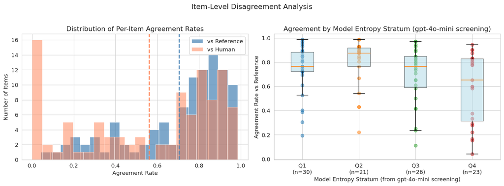

Saved output 2 · stream

```
=== Mean Agreement by Entropy Stratum ===
                 agree_rate_ref  agree_rate_human
entropy_stratum
Q1                        0.742             0.723
Q2                        0.789             0.671
Q3                        0.691             0.567
Q4                        0.589             0.241
```

Cell 28 · markdown

## Entropy Validation: Model-Generated Entropy as Item Difficulty Proxy

The entropy used for stratified sampling was computed from **gpt-4o-mini's self-reported probability vector** in the preliminary gpt-4o-mini screening pass — it is model-generated, not human-derived. We validate it here using an independent criterion:

**Cross-condition label diversity** — computed from G-Theory results across all 72 condition cells (4 evaluators × 3 prompts × 6 temps). If model-generated entropy (from a single gpt-4o-mini run) predicts multi-model disagreement in a completely independent experiment, it captures something about the *items* rather than being a single-model artifact.

Note: The DrugReview dataset has a single user rating per item (1–10 scale), so human annotation entropy cannot be computed directly from multiple raters.

**Original Markdown text**

```
## Entropy Validation: Model-Generated Entropy as Item Difficulty Proxy

The entropy used for stratified sampling was computed from **gpt-4o-mini's self-reported probability vector**
in the preliminary gpt-4o-mini screening pass — it is model-generated, not human-derived. We validate it here using an independent criterion:

**Cross-condition label diversity** — computed from G-Theory results across all 72 condition cells
(4 evaluators × 3 prompts × 6 temps). If model-generated entropy (from a single gpt-4o-mini run)
predicts multi-model disagreement in a completely independent experiment, it captures something about
the *items* rather than being a single-model artifact.

Note: The DrugReview dataset has a single user rating per item (1–10 scale),
so human annotation entropy cannot be computed directly from multiple raters.
```

Cell 29 · code · saved execution 19

```
# ── Cross-Condition Label Diversity from G-Theory ──
from scipy.stats import spearmanr, kruskal

# For each item, compute diversity metrics across 72 condition cells
item_gtheory = paired.groupby('item_id').agg(
    n_unique_labels=('pred_label', 'nunique'),
    modal_label=('pred_label', lambda x: x.mode().iloc[0]),
    modal_rate=('pred_label', lambda x: (x == x.mode().iloc[0]).mean()),
).reset_index()

# Label distribution entropy across 72 condition cells
def cross_condition_entropy(labels):
    counts = labels.value_counts(normalize=True)
    return -sum(p * np.log2(p) for p in counts if p > 0)

item_gtheory['cross_cond_entropy'] = paired.groupby('item_id')['pred_label'].apply(
    cross_condition_entropy
).values

# Load model entropy from sample file
sample_entropy = pd.read_csv(DATA_DIR / 'drug_sample_100.csv', usecols=['item_id', 'entropy', 'entropy_stratum'])
sample_entropy['item_id'] = sample_entropy['item_id'].astype(str)
sample_entropy = sample_entropy.rename(columns={'entropy': 'model_entropy'})

# Merge into validation DataFrame
val_df = sample_entropy.merge(item_gtheory, on='item_id', how='inner')

print(f'Validation items: {len(val_df)} (expected 100)')
print(f'\n=== Descriptive Statistics ===')
print(val_df[['model_entropy', 'cross_cond_entropy', 'n_unique_labels', 'modal_rate']].describe().round(3))

# ── Correlations ──
print(f'\n=== Spearman Correlations ===')
corr_pairs = [
    ('Model Entropy', 'Cross-Condition Entropy', 'model_entropy', 'cross_cond_entropy'),
    ('Model Entropy', 'N Unique Labels', 'model_entropy', 'n_unique_labels'),
    ('Model Entropy', '1 - Modal Rate', 'model_entropy', 'modal_rate'),
]

corr_rows = []
for name1, name2, col1, col2 in corr_pairs:
    vals1 = val_df[col1].values
    vals2 = val_df[col2].values
    if col2 == 'modal_rate':
        vals2 = 1 - vals2  # invert so higher = more disagreement
    rho, p = spearmanr(vals1, vals2)
    corr_rows.append({'Comparison': f'{name1} vs {name2}', 'Spearman rho': round(rho, 3), 'p-value': f'{p:.2e}'})
    print(f'  {name1} vs {name2}: rho={rho:.3f}, p={p:.2e}')

corr_table = pd.DataFrame(corr_rows)
display(corr_table)

# ── Kruskal-Wallis: Cross-condition entropy by entropy stratum ──
strata_order = ['Q1', 'Q2', 'Q3', 'Q4']  # Show all expected quantiles
strata_present = [s for s in strata_order if s in val_df['entropy_stratum'].values]
groups = [val_df[val_df['entropy_stratum'] == s]['cross_cond_entropy'].values for s in strata_present]
h_stat, p_kw = kruskal(*groups)
print(f'\n=== Kruskal-Wallis: Cross-Condition Entropy by Entropy Stratum ===')
print(f'  H={h_stat:.3f}, p={p_kw:.4f}')
print(f'  Stratum means:')
for s in strata_order:
    n_s = (val_df['entropy_stratum'] == s).sum()
    if n_s > 0:
        m = val_df[val_df['entropy_stratum'] == s]['cross_cond_entropy'].mean()
        print(f'    {s}: {m:.3f} (n={n_s})')
    else:
        print(f'    {s}: -- (n=0, stratum not in sample)')
```

Saved output 1 · stream

```
Validation items: 100 (expected 100)

=== Descriptive Statistics ===
       model_entropy  cross_cond_entropy  n_unique_labels  modal_rate
count        100.000             100.000          100.000     100.000
mean           1.650               0.797            2.710       0.769
std            0.372               0.339            0.591       0.144
min            0.881               0.106            2.000       0.361
25%            1.361               0.533            2.000       0.663
50%            1.716               0.825            3.000       0.799
75%            1.926               1.040            3.000       0.889
max            2.246               1.582            4.000       0.986

=== Spearman Correlations ===
  Model Entropy vs Cross-Condition Entropy: rho=0.287, p=3.83e-03
  Model Entropy vs N Unique Labels: rho=0.127, p=2.07e-01
  Model Entropy vs 1 - Modal Rate: rho=0.235, p=1.87e-02
```

Saved output 2 · display_data

**Saved plain-text representation**

```
                                 Comparison  Spearman rho   p-value
0  Model Entropy vs Cross-Condition Entropy         0.287  3.83e-03
1          Model Entropy vs N Unique Labels         0.127  2.07e-01
2           Model Entropy vs 1 - Modal Rate         0.235  1.87e-02
```

|  | Comparison | Spearman rho | p-value |
| --- | --- | --- | --- |
| 0 | Model Entropy vs Cross-Condition Entropy | 0.287 | 3.83e-03 |
| 1 | Model Entropy vs N Unique Labels | 0.127 | 2.07e-01 |
| 2 | Model Entropy vs 1 - Modal Rate | 0.235 | 1.87e-02 |

**Complete saved HTML representation (inert source)**

[output not shown]

**Saved application/vnd.google.colaboratory.intrinsic+json representation**

[output not shown]

Saved output 3 · stream

```
=== Kruskal-Wallis: Cross-Condition Entropy by Entropy Stratum ===
  H=11.676, p=0.0086
  Stratum means:
    Q1: 0.749 (n=30)
    Q2: 0.623 (n=21)
    Q3: 0.818 (n=26)
    Q4: 0.992 (n=23)
```

Cell 30 · code · saved execution 20

```
# ── Visualization: Entropy Validation ──
fig, axes = plt.subplots(1, 2, figsize=(14, 6))

strata_order = ['Q1', 'Q2', 'Q3', 'Q4']  # Show all expected quantiles
colors = {'Q1': 'green', 'Q2': 'dodgerblue', 'Q3': 'orange', 'Q4': 'red'}

# Panel 1: Model Entropy vs Cross-Condition Entropy (scatter)
ax = axes[0]
for stratum in strata_order:
    sub = val_df[val_df['entropy_stratum'] == stratum]
    if len(sub) > 0:
        ax.scatter(sub['model_entropy'], sub['cross_cond_entropy'],
                   c=colors.get(stratum, 'gray'), label=stratum, alpha=0.7, s=50, edgecolors='white')
    else:
        ax.scatter([], [], c=colors.get(stratum, 'gray'), label=f'{stratum} (n=0)', alpha=0.7, s=50, edgecolors='white')
rho, p = spearmanr(val_df['model_entropy'], val_df['cross_cond_entropy'])
ax.set_xlabel('Model Entropy (gpt-4o-mini probability vector, screening pass)')
ax.set_ylabel('Cross-Condition Label Entropy (G-Theory, 72 cells)')
ax.set_title(f'Model Entropy vs Multi-Model Diversity (\u03c1={rho:.3f}, p={p:.2e})')
ax.legend(title='Stratum')
# Regression line
z = np.polyfit(val_df['model_entropy'], val_df['cross_cond_entropy'], 1)
x_line = np.linspace(val_df['model_entropy'].min(), val_df['model_entropy'].max(), 100)
ax.plot(x_line, np.polyval(z, x_line), 'k--', alpha=0.5)

# Panel 2: Cross-Condition Entropy by Entropy Stratum (box + strip)
ax = axes[1]
boxdata = [val_df[val_df['entropy_stratum'] == s]['cross_cond_entropy'].values
           if s in val_df['entropy_stratum'].values else np.array([])
           for s in strata_order]
bp = ax.boxplot(boxdata, positions=range(len(strata_order)), widths=0.5,
                patch_artist=True, showfliers=False)
palette = [colors.get(s, 'gray') for s in strata_order]
for patch, color in zip(bp['boxes'], palette):
    patch.set_facecolor(color)
    patch.set_alpha(0.3)
for i, s in enumerate(strata_order):
    sub = val_df[val_df['entropy_stratum'] == s]
    if len(sub) > 0:
        ax.scatter([i] * len(sub), sub['cross_cond_entropy'],
                   c=colors.get(s, 'gray'), alpha=0.6, s=30, zorder=3)
    else:
        ax.text(i, 0.5, 'n=0', ha='center', va='center', fontsize=9, color='gray', style='italic')
ax.set_xticks(range(len(strata_order)))
tick_labels = [f'{s}\n(n={(val_df["entropy_stratum"]==s).sum()})' for s in strata_order]
ax.set_xticklabels(tick_labels)
ax.set_xlabel('Model Entropy Stratum (from gpt-4o-mini screening)')
ax.set_ylabel('Cross-Condition Label Entropy (G-Theory)')
ax.set_title('G-Theory Label Diversity by gpt-4o-mini Screening Entropy Stratum')

fig.suptitle('Entropy Validation \u2014 Drug Review', fontsize=14, y=1.02)
plt.tight_layout()
plt.savefig(OUTPUTS_DIR / 'drug_entropy_validation.png', dpi=150, bbox_inches='tight')
plt.show()

# Save
val_df.to_csv(OUTPUTS_DIR / 'drug_entropy_validation.csv', index=False)
corr_table.to_csv(OUTPUTS_DIR / 'drug_entropy_correlations.csv', index=False)
print(f'Saved to {OUTPUTS_DIR}')
```

Saved output 1 · display_data

**Saved plain-text representation**

```
<Figure size 1680x720 with 2 Axes>
```

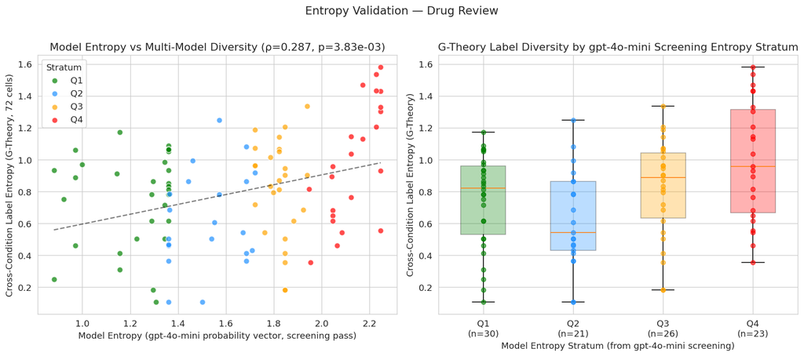

Saved output 2 · stream

```
Saved to ./03.DrugReview/outputs
```

Cell 31 · markdown

## Summary

**Original Markdown text**

```
## Summary
```

Cell 32 · code · saved execution 21

```
# Compile summary
summary_rows = [
    {'level': 'L1: Per Cell (72 cells, n=100)',
     'mean_agr_ref': level1['agr_ref'].mean(),
     'std_agr_ref': level1['agr_ref'].std(),
     'mean_kw_ref': level1['kappa_ref'].mean(),
     'mean_agr_human': level1['agr_human'].mean(),
     'mean_kw_human': level1['kappa_human'].mean()},
    {'level': 'L2: Eval\u00d7Prompt (12 cells, n=600)',
     'mean_agr_ref': level2['agr_ref'].mean(),
     'std_agr_ref': level2['agr_ref'].std(),
     'mean_kw_ref': level2['kappa_ref'].mean(),
     'mean_agr_human': level2['agr_human'].mean(),
     'mean_kw_human': level2['kappa_human'].mean()},
    {'level': 'L3: Per Eval (4 cells, n=1800)',
     'mean_agr_ref': level3['agr_ref'].mean(),
     'std_agr_ref': level3['agr_ref'].std(),
     'mean_kw_ref': level3['kappa_ref'].mean(),
     'mean_agr_human': level3['agr_human'].mean(),
     'mean_kw_human': level3['kappa_human'].mean()},
    {'level': 'L4: Overall (n=7200)',
     'mean_agr_ref': m_orig['agreement'],
     'std_agr_ref': 0,
     'mean_kw_ref': m_orig['kappa'],
     'mean_agr_human': m_human['agreement'],
     'mean_kw_human': m_human['kappa']},
]

summary = pd.DataFrame(summary_rows)
print("=" * 80)
print("AGREEMENT ANALYSIS SUMMARY \u2014 Drug Review")
print("=" * 80)
display(summary.round(3))

# Save
summary.to_csv(OUTPUTS_DIR / 'drug_agreement_summary.csv', index=False)
level1.to_csv(OUTPUTS_DIR / 'drug_agreement_L1_detail.csv', index=False)
print(f"\nSaved to {OUTPUTS_DIR}")
```

Saved output 1 · stream

```
================================================================================
AGREEMENT ANALYSIS SUMMARY — Drug Review
================================================================================
```

Saved output 2 · display_data

**Saved plain-text representation**

[output not shown]

[output not shown]

**Complete saved HTML representation (inert source)**

[output not shown]

**Saved application/vnd.google.colaboratory.intrinsic+json representation**

[output not shown]

Saved output 3 · stream

```
Saved to ./03.DrugReview/outputs
```